# Medical_data_specificity_tasks

NataliaLaskina

2024-11-02

#Чтение данных

```r
trauma_data <- read_excel('C:/Users/laskn/BioStat_2024/data/originals/trauma.xlsx')

trauma_data %>% summary()
```

```
##        id             Name               Sex                 Age
##  Min.   :   1.0   Length:1024        Length:1024        Min.   :18.00
##  1st Qu.: 256.8   Class :character   Class :character   1st Qu.:29.00
##  Median : 512.5   Mode  :character   Mode  :character   Median :41.00
##  Mean   : 512.5                                         Mean   :40.94
##  3rd Qu.: 768.2                                         3rd Qu.:53.00
##  Max.   :1024.0                                         Max.   :64.00
##     Height              Weight           SBP             DBP
##  Length:1024        Min.   :133.3   Min.   : 90.0   Min.   : 58.00
##  Class :character   1st Qu.:181.7   1st Qu.:106.0   1st Qu.: 78.00
##  Mode  :character   Median :193.9   Median :110.0   Median : 84.00
##                     Mean   :193.5   Mean   :110.8   Mean   : 84.78
##                     3rd Qu.:205.4   3rd Qu.:116.0   3rd Qu.: 90.00
##                     Max.   :253.1   Max.   :134.0   Max.   :110.00
##       FOUR             GSC               Hb           Death
##  Min.   : 0.000   Min.   : 3.000   Min.   : 0.0   Min.   :0.0000
##  1st Qu.: 7.000   1st Qu.: 6.000   1st Qu.:12.0   1st Qu.:0.0000
##  Median : 9.000   Median : 8.000   Median :13.1   Median :0.0000
##  Mean   : 8.853   Mean   : 7.785   Mean   :12.8   Mean   :0.3994
##  3rd Qu.:11.000   3rd Qu.:10.000   3rd Qu.:14.0   3rd Qu.:1.0000
##  Max.   :16.000   Max.   :14.000   Max.   :16.2   Max.   :1.0000
```

#Форматирование данных

```r
trauma_data <- trauma_data %>%
    mutate(across(c(id, Sex, Death), ~ as.factor(.x)))

trauma_data$Height <- gsub('"', '', trauma_data$Height)

trauma_data$Height <- as.numeric(trauma_data$Height)

trauma_data %>% summary()
```

```
##        id           Name               Sex           Age            Height
##  1      :   1   Length:1024        Female:384   Min.   :18.00   Min.   :63.80
##  2      :   1   Class :character   Male  :640   1st Qu.:29.00   1st Qu.:69.70
##  3      :   1   Mode  :character                Median :41.00   Median :72.80
##  4      :   1                                   Mean   :40.94   Mean   :72.42
##  5      :   1                                   3rd Qu.:53.00   3rd Qu.:75.10
##  6      :   1                                   Max.   :64.00   Max.   :79.90
##  (Other):1018
##      Weight           SBP             DBP              FOUR
##  Min.   :133.3   Min.   : 90.0   Min.   : 58.00   Min.   : 0.000
##  1st Qu.:181.7   1st Qu.:106.0   1st Qu.: 78.00   1st Qu.: 7.000
##  Median :193.9   Median :110.0   Median : 84.00   Median : 9.000
##  Mean   :193.5   Mean   :110.8   Mean   : 84.78   Mean   : 8.853
##  3rd Qu.:205.4   3rd Qu.:116.0   3rd Qu.: 90.00   3rd Qu.:11.000
##  Max.   :253.1   Max.   :134.0   Max.   :110.00   Max.   :16.000
##
##       GSC               Hb       Death
##  Min.   : 3.000   Min.   : 0.0   0:615
##  1st Qu.: 6.000   1st Qu.:12.0   1:409
##  Median : 8.000   Median :13.1
##  Mean   : 7.785   Mean   :12.8
##  3rd Qu.:10.000   3rd Qu.:14.0
##  Max.   :14.000   Max.   :16.2
##
```

#Перевод в нужные единицы измерения, добавление переменной BMI

```r
trauma_data_cleaned <- trauma_data %>%

    mutate(

        # Заменим единицы в дюймах на единицы в метрах
        Height = round(Height * 0.0254, 1),
        # Преобразуем Weight из фунтов в килограммы
        Weight = round(Weight * 0.453592, 1),

       # Заменим "0" на пропущенные значения
        Hb = na_if(Hb, 0),

        BMI = (Weight / Height / Height) %>% round(1)

        )

trauma_data_cleaned %>% head()
```

```
## # A tibble: 6 × 13
##   id    Name       Sex     Age Height Weight   SBP   DBP  FOUR   GSC    Hb Death
##   <fct> <chr>      <fct> <dbl>  <dbl>  <dbl> <dbl> <dbl> <dbl> <dbl> <dbl> <fct>
## 1 1     Jecelle O… Fema…    24    1.7   79.8   102    78    10     8  11.4 1
## 2 2     Halie Mcc… Fema…    35    1.8   83.4   116    86     9     7  12.2 0
## 3 3     Kole Cook  Male     39    1.8   95.3   122   102    12    12  15   0
## 4 4     Patricia … Fema…    20    1.8   88.6   120   100    11     9  12.2 0
## 5 5     Grace Cre… Fema…    63    1.7   76.7   112    84     9     7  12.4 1
## 6 6     Joseph Be… Male     60    1.8   91.4   118    88    13    11  15   0
## # ℹ 1 more variable: BMI <dbl>
```

```r
trauma_data_cleaned %>% summary()
```

```
##        id           Name               Sex           Age            Height
##  1      :   1   Length:1024        Female:384   Min.   :18.00   Min.   :1.600
##  2      :   1   Class :character   Male  :640   1st Qu.:29.00   1st Qu.:1.800
##  3      :   1   Mode  :character                Median :41.00   Median :1.800
##  4      :   1                                   Mean   :40.94   Mean   :1.839
##  5      :   1                                   3rd Qu.:53.00   3rd Qu.:1.900
##  6      :   1                                   Max.   :64.00   Max.   :2.000
##  (Other):1018
##      Weight            SBP             DBP              FOUR
##  Min.   : 60.50   Min.   : 90.0   Min.   : 58.00   Min.   : 0.000
##  1st Qu.: 82.40   1st Qu.:106.0   1st Qu.: 78.00   1st Qu.: 7.000
##  Median : 88.00   Median :110.0   Median : 84.00   Median : 9.000
##  Mean   : 87.78   Mean   :110.8   Mean   : 84.78   Mean   : 8.853
##  3rd Qu.: 93.20   3rd Qu.:116.0   3rd Qu.: 90.00   3rd Qu.:11.000
##  Max.   :114.80   Max.   :134.0   Max.   :110.00   Max.   :16.000
##
##       GSC               Hb        Death        BMI
##  Min.   : 3.000   Min.   : 9.40   0:615   Min.   :18.70
##  1st Qu.: 6.000   1st Qu.:12.10   1:409   1st Qu.:24.20
##  Median : 8.000   Median :13.10           Median :25.90
##  Mean   : 7.785   Mean   :13.01           Mean   :26.05
##  3rd Qu.:10.000   3rd Qu.:14.00           3rd Qu.:27.80
##  Max.   :14.000   Max.   :16.20           Max.   :35.00
##                   NA's   :16
```

#Пациенты со сниженным уровнем гемоглобина

```r
trauma_data_cleaned <- trauma_data_cleaned %>%
  mutate(
    Hb_Low = case_when(
      Sex == "Male" & Hb < 13.5 ~ TRUE,
      Sex == "Female" & Hb < 12 ~ TRUE,
      TRUE ~ FALSE
    )
  )

# Считаем количество пациентов с низким Hb
n_low_hb <- sum(trauma_data_cleaned$Hb_Low, na.rm = TRUE)

percent_low_hb <- (n_low_hb / nrow(trauma_data_cleaned)) * 100

cat("У", n_low_hb, "пациентов (", round(percent_low_hb, 1), "%) был снижен уровень гемоглобина.\n")
```

```
## У 458 пациентов ( 44.7 %) был снижен уровень гемоглобина.
```

#Средний BMI, доля людей с ожирением

```r
# Средний ИМТ
mean_bmi <- mean(trauma_data_cleaned$BMI, na.rm = TRUE)
sd_bmi <- sd(trauma_data_cleaned$BMI, na.rm = TRUE)

# Доля пациентов с ожирением
n_obese <- sum(trauma_data_cleaned$BMI > 30, na.rm = TRUE)
percent_obese <- (n_obese / nrow(trauma_data_cleaned)) * 100

# Выводим результат
cat("Средний ИМТ:", round(mean_bmi, 2), "(", round(sd_bmi, 2), ")\n")
```

```
## Средний ИМТ: 26.05 ( 2.7 )
```

```r
cat("Доля пациентов с ожирением:", round(percent_obese, 1), "%\n")
```

```
## Доля пациентов с ожирением: 7.9 %
```

#Сравнение показателей по переменной Death

```r
trauma_data_cleaned %>%
    select(Sex,
           Age,
           Height,
           Weight,
           BMI,
           SBP,
           DBP,
           FOUR,
           GSC,
           Hb,
           Death) %>%
    tbl_summary(by = Death)
```

| **Characteristic** | **0** N = 615<sup>1</sup> | **1** N = 409<sup>1</sup> |
| --- | --- | --- |
| Sex |  |  |
| Female | 226 (37%) | 158 (39%) |
| Male | 389 (63%) | 251 (61%) |
| Age | 40 (29, 52) | 43 (30, 53) |
| Height |  |  |
| 1.6 | 5 (0.8%) | 2 (0.5%) |
| 1.7 | 98 (16%) | 81 (20%) |
| 1.8 | 207 (34%) | 122 (30%) |
| 1.9 | 251 (41%) | 179 (44%) |
| 2 | 54 (8.8%) | 25 (6.1%) |
| Weight | 88 (83, 93) | 88 (82, 93) |
| BMI | 25.90 (24.20, 27.80) | 25.90 (24.30, 27.70) |
| SBP | 114 (108, 118) | 106 (102, 110) |
| DBP | 88 (82, 94) | 80 (76, 86) |
| FOUR | 10.0 (9.0, 12.0) | 6.0 (5.0, 8.0) |
| GSC | 9.00 (8.00, 11.00) | 5.00 (4.00, 7.00) |
| Hb | 13.50 (12.50, 14.30) | 12.70 (11.40, 13.30) |
| Unknown | 10 | 6 |

<sup>1</sup> n (%); Median (Q1, Q3)

# Анализ ROC-кривых

## Death ~ Hb

### ROC-анализ для Death ~ Hb

```r
roc_curve_1 <- roc(Death ~ Hb,
                   data = trauma_data_cleaned,
                   ci = T)
roc_curve_1
```

```
##
## Call:
## roc.formula(formula = Death ~ Hb, data = trauma_data_cleaned,     ci = T)
##
## Data: Hb in 605 controls (Death 0) > 403 cases (Death 1).
## Area under the curve: 0.7078
## 95% CI: 0.6763-0.7392 (DeLong)
```

###ROC-кривая для Death ~ Hb

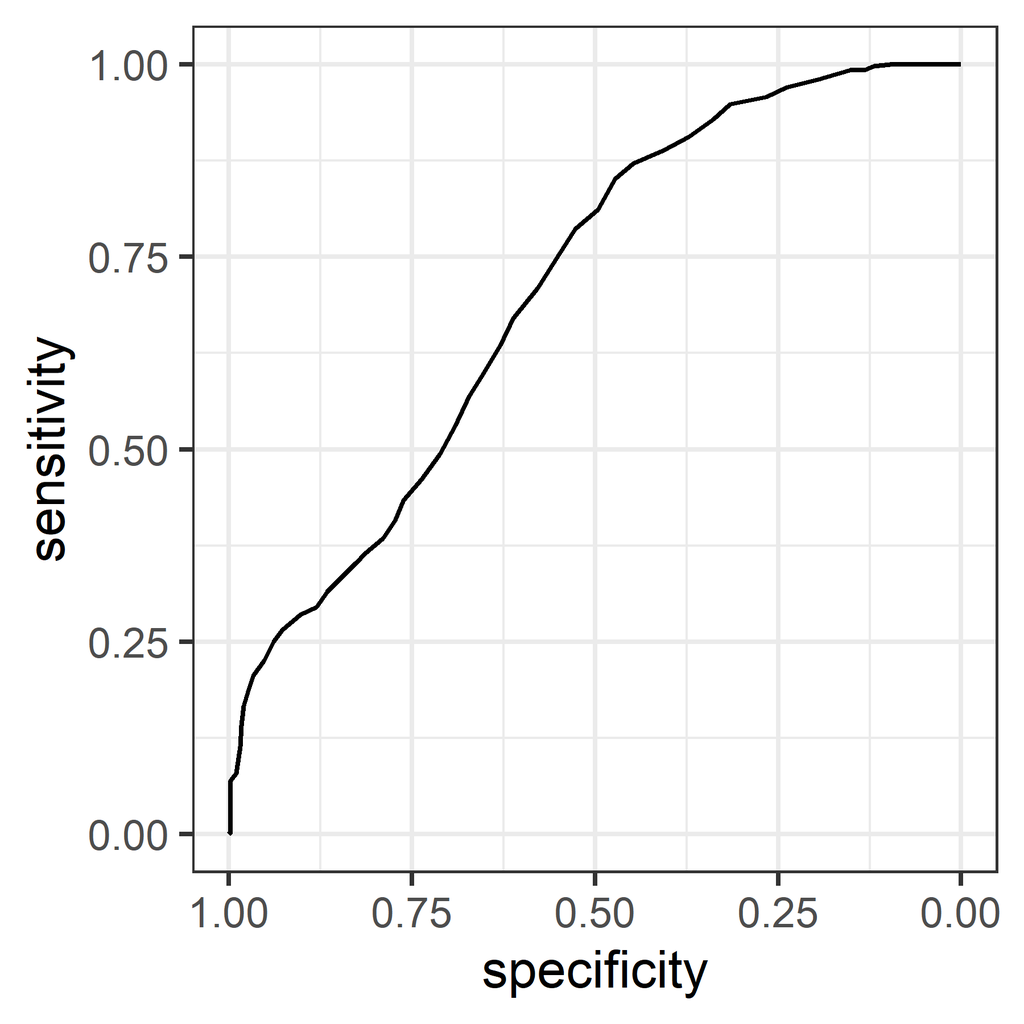

```r
roc_curve_1 %>%
    ggroc() +
    theme_bw()
```

Площадь под ROC-кривой равна 0.7078. 95% двусторонний ДИ для площади под ROC-кривой равен 0.6763-0.7392

Уровень гемоглобина обладает умеренной дискриминационной способностью в предсказании летального исхода в течение 24 часов у пациентов с черепно-мозговой травмой от падения с электросамоката. Неидеальный, но информативный предиктор: модель не идеальна, но значительно лучше случайного предсказания (AUC = 0.5). Уверенность в оценке: доверительный интервал не включает значение 0.5, что подтверждает статистическую значимость связи между уровнем гемоглобина и вероятностью летального исхода.

Возможные причины “неидеальной” формы кривой:

Возможно, что уровень гемоглобина не линейно связан с летальным исходом. Например, может быть высокий риск смерти при очень низком и очень высоком гемоглобине, а при нормальных значениях риск может быть ниже. Другие факторы: вероятно, что летальный исход зависит от многих других факторов, кроме уровня гемоглобина. Например, тяжесть травмы, возраст, сопутствующие заболевания.

### Координаты для Death ~ Hb

```r
roc_curve_1 %>% coords()
```

```
##    threshold specificity sensitivity
## 1        Inf 0.000000000 1.000000000
## 2      16.05 0.001652893 1.000000000
## 3      15.85 0.004958678 1.000000000
## 4      15.75 0.009917355 1.000000000
## 5      15.65 0.013223140 1.000000000
## 6      15.50 0.016528926 1.000000000
## 7      15.35 0.026446281 1.000000000
## 8      15.25 0.028099174 1.000000000
## 9      15.15 0.034710744 1.000000000
## 10     15.05 0.054545455 1.000000000
## 11     14.95 0.080991736 1.000000000
## 12     14.85 0.097520661 1.000000000
## 13     14.75 0.119008264 0.997518610
## 14     14.65 0.132231405 0.992555831
```

[output cut: 53 more lines]

###Выбор лучшего порога для Death ~ Hb

```r
roc_curve_1 %>% coords(x = "best", best.method = "closest.topleft")
```

```
##   threshold specificity sensitivity
## 1     13.15   0.6115702   0.6699752
```

Пороговое значение 13.15 является оптимальным для предсказания летального исхода в течение 24 часов по уровню гемоглобина. Этот порог обладает чувствительностью 0.67 и специфичностью 0.61

## Death ~ GSC

### ROC-анализ для Death ~ GSC

```r
roc_curve_2 <- roc(Death ~ GSC,
                   data = trauma_data_cleaned,
                   ci = T)
roc_curve_2
```

```
##
## Call:
## roc.formula(formula = Death ~ GSC, data = trauma_data_cleaned,     ci = T)
##
## Data: GSC in 615 controls (Death 0) > 409 cases (Death 1).
## Area under the curve: 0.9124
## 95% CI: 0.8959-0.9289 (DeLong)
```

###ROC-кривая для Death ~ GSC

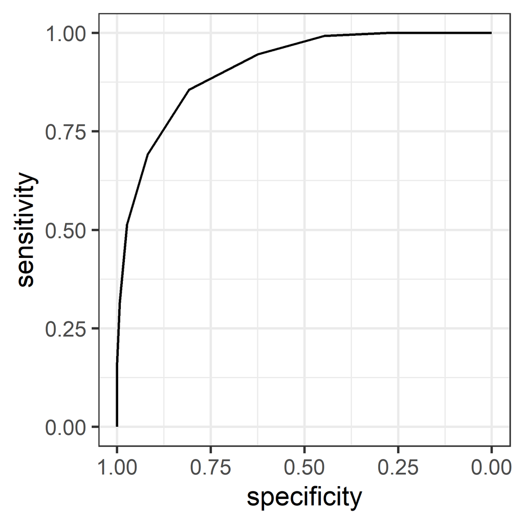

```r
roc_curve_2 %>%
    ggroc() +
    theme_bw()
```

Площадь под ROC-кривой равна 0.9124. 95% двусторонний ДИ для площади под ROC-кривой равен 0.8959-0.9289 Выглядит, как показатель с почти идеальной дискриминационной способностью в предсказании летального исхода в течение 24 часов у пациентов с черепно-мозговой травмой от падения с электросамоката.

### Координаты для Death ~ GSC

```r
roc_curve_2 %>% coords()
```

```
##    threshold specificity sensitivity
## 1        Inf  0.00000000   1.0000000
## 2       13.5  0.02926829   1.0000000
## 3       12.5  0.06666667   1.0000000
## 4       11.5  0.14796748   1.0000000
## 5       10.5  0.28130081   1.0000000
## 6        9.5  0.44715447   0.9926650
## 7        8.5  0.62439024   0.9462103
## 8        7.5  0.80813008   0.8557457
## 9        6.5  0.91869919   0.6919315
## 10       5.5  0.97398374   0.5134474
## 11       4.5  0.99349593   0.3154034
## 12       3.5  1.00000000   0.1638142
## 13      -Inf  1.00000000   0.0000000
```

###Выбор лучшего порога для Death ~ GSC

```r
roc_curve_2 %>% coords(x = "best", best.method = "closest.topleft")
```

```
##   threshold specificity sensitivity
## 1       7.5   0.8081301   0.8557457
```

Пороговое значение 7.5 (по шкале между 7 и 8) является оптимальным для предсказания летального исхода в течение 24 часов по шкале комы Глазго. Этот порог обладает чувствительностью 0.86 и специфичностью 0.81

## ROC-анализ для показателя Death ~ все переменные

```r
trauma_data_cleaned %>% names()
```

```
##  [1] "id"     "Name"   "Sex"    "Age"    "Height" "Weight" "SBP"    "DBP"
##  [9] "FOUR"   "GSC"    "Hb"     "Death"  "BMI"    "Hb_Low"
```

```r
trauma_data_cleaned %>%

    select("Death",
           "Age",
           "Height",
           "Weight",
           "BMI",
           "SBP",
           "DBP",
           "FOUR",
           "GSC",
           "Hb"
           ) %>%

    pivot_longer(cols = !Death) %>%

    group_by(name) %>%

    summarise(AUC = roc(Death, value, ci = T)$ci[2] %>% round(3),
              AUC_LCL = roc(Death, value, ci = T)$ci[1] %>% round(3),
              AUC_UCL = roc(Death, value, ci = T)$ci[3] %>% round(3))
```

```
## # A tibble: 9 × 4
##   name     AUC AUC_LCL AUC_UCL
##   <chr>  <dbl>   <dbl>   <dbl>
## 1 Age    0.527   0.491   0.563
## 2 BMI    0.501   0.465   0.538
## 3 DBP    0.744   0.714   0.774
## 4 FOUR   0.934   0.92    0.948
## 5 GSC    0.912   0.896   0.929
## 6 Hb     0.708   0.676   0.739
## 7 Height 0.486   0.452   0.52
## 8 SBP    0.786   0.759   0.814
## 9 Weight 0.518   0.482   0.554
```

Наибольшей площадью под ROC-кривой обладает балл по шкале комы FOUR при поступлении - 0.934 . Этот показатель (из имеющихся) с лучшей дискриминационной способностью в предсказании летального исхода в течение 24 часов у пациентов с черепно-мозговой травмой от падения с электросамоката. Наименьшей площадью под ROC-кривой обладает переменная рост (Height) - 0.486 - дискриминационная способность на уровне случайного предсказания.